# Week3: Control flow and functions

## Loops

### For-loop

The for loop can be used to repeat a set of instructions, and it is used when you know in advance the values that the loop variable will have each time it goes through the loop. The basic format for the for loop is for(var in seq) expr

```r
for (x in 1:10) {
  cat(x^2, "\n")
}
```

```
#> 1
#> 4
#> 9
#> 16
#> 25
#> 36
#> 49
#> 64
#> 81
#> 100
```

**Try:**

Print the city names line-by-line

```r
cities <- c("New York", "Paris",
            "London", "Tokyo",
            "Rio de Janeiro", "Cape Town")

for(var in seq) {
  expr
}
```

**Advanced:**

Print index and cicy names

```r
cities <- c("New York", "Paris",
            "London", "Tokyo",
            "Rio de Janeiro", "Cape Town")

for(i in 1:length(cities)) {
  cat(i, cities[i], "\n")
}
```

```
#> 1 New York
#> 2 Paris
#> 3 London
#> 4 Tokyo
#> 5 Rio de Janeiro
#> 6 Cape Town
```

## Introduction to Programming

### Equality

The most basic form of comparison is equality. Let’s briefly recap its syntax. The following statements all evaluate to `TRUE` (feel free to try them out in the console).

```r
3 == (2 + 1)
"intermediate" != "r"
TRUE != FALSE
"Rchitect" != "rchitect"
```

**Try:**

- In the editor on the right, write R code to see if `TRUE` equals `FALSE`.
- Likewise, check if `-6 * 14` is not equal to `17 - 101`.
- Next up: comparison of character strings. Ask R whether the strings `"useR"` and `"user"` are equal.
- Finally, find out what happens if you compare logicals to numerics: are `TRUE` and `1` equal?

```r
# Comparison of logicals


# Comparison of numerics


# Comparison of character strings


# Compare a logical with a numeric
```

### Greater and less than

Apart from equality operators, Filip also introduced the less than and greater than operators: `<` and `>`. You can also add an equal sign to express less than or equal to or greater than or equal to, respectively. Have a look at the following R expressions, that all evaluate to `FALSE`:

```r
(1 + 2) > 4
"dog" < "Cats"
TRUE <= FALSE
```

**Try:**

- `-6 * 5 + 2` is greater than or equal to `-10 + 1`.
- `"raining"` is less than or equal to `"raining dogs"`.
- `TRUE` is greater than `FALSE`.

### Compare vectors

```r
# The linkedin and facebook vectors have already been created for you
linkedin <- c(16, 9, 13, 5, 2, 17, 14)
facebook <- c(17, 7, 5, 16, 8, 13, 14)

# Popular days: On which days did the number of LinkedIn profile views exceed 15?


# Quiet days: When was your LinkedIn profile viewed only 5 times or fewer?


# LinkedIn more popular than Facebook:
# When was your LinkedIn profile visited more often than your Facebook profile?
```

### Logical Operators: & and |

真值表：

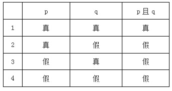

```r
TRUE & TRUE
```

```
#> [1] TRUE
```

```r
FALSE | TRUE
```

```
#> [1] TRUE
```

```r
5 <= 5 & 2 < 3
```

```
#> [1] TRUE
```

```r
3 < 4 | 7 < 6
```

```
#> [1] TRUE
```

> Watch out: `3 < x < 7` to check if `x` is between 3 and 7 will not work; you’ll need `3 < x & x < 7` for that.

**Try:**

```r
# The linkedin and last variable are already defined for you
linkedin <- c(16, 9, 13, 5, 2, 17, 14)
last <- tail(linkedin, 1)

# Is last under 5 or above 10?


# Is last between 15 (exclusive) and 20 (inclusive)?
```

### The if statement

```r
if (condition) {
  expr
}
```

```r
# Variables related to your last day of recordings
medium <- "LinkedIn"
num_views <- 14

# Examine the if statement for medium: Examine the if statement that prints out "Showing LinkedIn information" if the medium variable equals "LinkedIn".
if (medium == "LinkedIn") {
  print("Showing LinkedIn information")
}
```

```
#> [1] "Showing LinkedIn information"
```

```r
# Write the if statement for num_views: Code an if statement that prints "You're popular!" to the console if the num_views variable exceeds 15.
```

### Writing a function in R

`my_fun` is the variable that you want to assign your function to, arg1 and arg2 are arguments to the function.

```r
my_fun <- function(arg1, arg2) {
  # body
}
```

**Try:**

1. Using the function template, write a function `ratio()` that takes arguments `x` and `y` and returns their ratio, `x / y`.
2. Check your function by calling it with the arguments 3 and 4.

```r
# Define ratio() function
ratio <- function(arg1, arg2) {
  arg1 / arg2
}

# Call ratio() with arguments 3 and 4
ratio(3, 4)
```

You probably either did `ratio(3, 4)`, which relies on **matching by position**, or `ratio(x = 3, y = 4)`, which relies on **matching by name**.

**Conventions to call a function**

1. For functions you and others use often, it’s okay to use positional matching for the first one or two arguments. (These are usually the data to be computed on)
2. Beyond the first couple of arguments you should always use matching by name.
3. . Notice that when you call a function, you should place a space around `=` in function calls,

**Try:**

Here’s a rather cryptic call to `mean()`. Rewrite the call to follow the best practices we just discussed. Use the natural ordering of the arguments, which you can find by typing ?mean in the console.

```r
# Rewrite the call to follow best practices
mean(0.1,x=c(1:9, NA),TRUE)
```

**Quiz**

```r
f <- function(x) {
  if (TRUE) {
    return(x + 1)
  }
  x
}
```

What will be the result of calling `f(2)`?

## Assignment

Load the `pokemon` dataset by

```r
library(dplyr)
pokemon <- readr::read_csv("https://github.com/leoluyi/R-basic-tutorial-201708/raw/gh-pages/data/pokemons.csv")
View(pokemon)
```

1. Write an `if` statement for `pokemon$BaseAttack`: Code an if statement that prints “Mean BaseAttack is greater than 150!” to the console if the mean of `BaseAttack` variable exceeds 150.